# Week 3 Lab Companion: Regression for Association

Companion document with more advanced coding methods

Author

Chris Zuidema for ENVH 556 Autumn 2024

This document was rendered on October 17, 2024.

**NOTE: This document was developed in 2021 and has not been updated. You are free to use this document as an additional resource.**

# Purpose

This document is a companion to the `Week3Lab.Rmd`. The purpose is to provide additional and somewhat more sophisticated coding methods to supplement the approaches demonstrated in Lab 3; you may find these more advanced coding methods useful for your own work. Our coding goals for `Week3Lab.Rmd` were clarity and transparency to support learning about regression. Here we demonstrate some techniques that will scale well (for example to many regression models), reduce code repetition, and reduce the amount of “hard coding” in the analysis, but that are less explicit and may obscure what is going on “behind the scenes” a bit. As with `Week3Lab.Rmd`, this document will use the snapshot data.

# Preliminaries

These preliminary steps are the same as `Week3Lab.Rmd` and are included for completeness.

## Prepare snapshot dataframe

```r
#-----prep snapshot-----

# transform snapshot dataframe to tibble and modify season factor
snapshot <- snapshot %>%
  as_tibble() %>%
  mutate(seasonfac = factor(str_remove(seasonfac, "[:digit:]"),
         levels = c("Summer", "Fall", "Winter")) )

# create season variable (to be used throughout analysis)
seasons <- unique(snapshot$seasonfac)
```

## Summarize *ln_nox* by season

```r
#-----summarize ln_nox-----

# frequencies only
summary(snapshot$seasonfac)
```

```
Summer   Fall Winter
   148    152    149
```

```r
# descriptive statistics
snapshot_summary <- snapshot %>%
    group_by(seasonfac) %>%
    summarise(N = n(),
              Mean = mean(ln_nox),
              SD = sd(ln_nox),
              GM = exp(mean(ln_nox)),
              GSD = exp(sd(ln_nox)),
              .groups = "drop") %>%
    mutate_if(is.double, round, digits = 2)

# show summary
snapshot_summary
```

```
# A tibble: 3 × 6
  seasonfac     N  Mean    SD    GM   GSD
  <fct>     <int> <dbl> <dbl> <dbl> <dbl>
1 Summer      148  3.47  0.39  32.1  1.47
2 Fall        152  4.27  0.32  71.5  1.37
3 Winter      149  4.51  0.3   91.3  1.35
```

## Season-specific boxplots

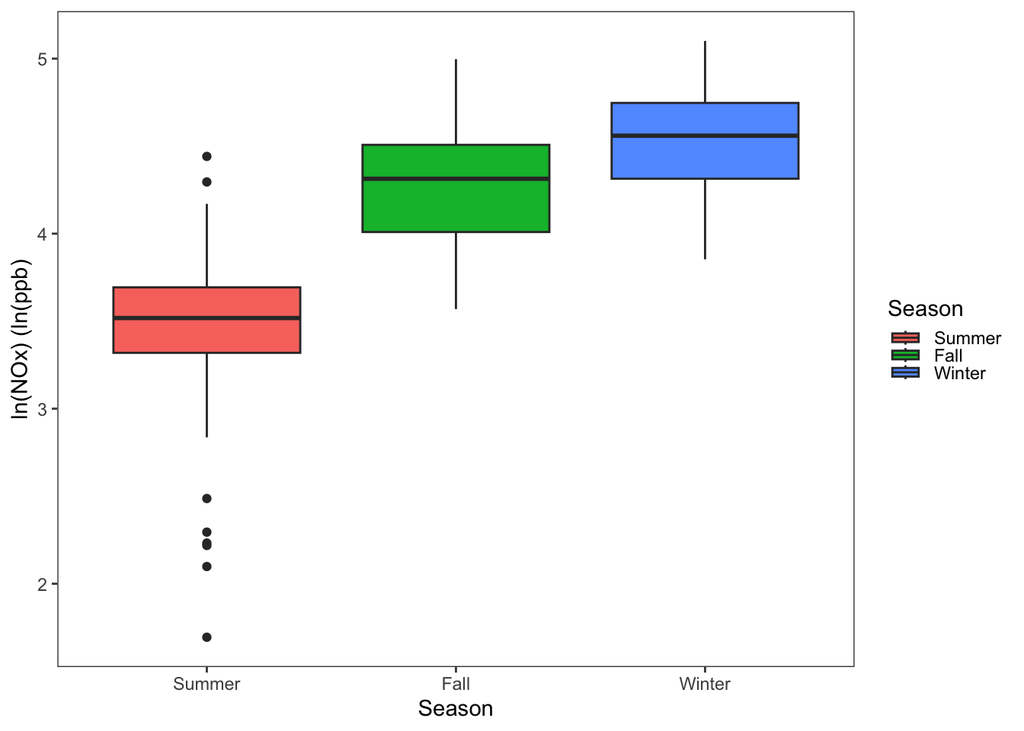

```r
#-----season-specific boxplots-----

ggplot(snapshot, aes(x = seasonfac, y = ln_nox, fill = seasonfac)) +
    geom_boxplot() +
    labs(x = "Season",
         y = "ln(NOx) (ln(ppb)",
         color = "Season",
         fill = "Season") +
    theme_article()
```

# Regression analysis

`Week3Lab.Rmd` takes a more manual approach to regression modeling by specifying each of the seasonal models separately and assigning each model fit to its own object. This approach is clear and easy to follow, but you can see how this would quickly become a burdensome exercise potentially fraught with errors due to its reliance on copy/paste and repeated code. Imagine if we had 20 seasons instead of 3. In this section, we explore the general nesting workflow, where data is grouped and modeling steps occur “within” a dataframe. Aside from managing analysis steps with groups programmatically, these functions package regression output in dataframes that are `ggplot` friendly, thus minimizing the data wrangling required before plotting.

You can find more information about the nested workflow here:

- Tidyverse [“Nested Data”](https://tidyr.tidyverse.org/articles/nest.html)
- Bookdown [“Many Models”](https://r4ds.had.co.nz/many-models.html)

```r
#-----regression for association-----

# Common model (Table 4), season-specific LUR from Mercer et al, 2011

# specify the "common model"
frml <-
  as.formula(ln_nox ~ D2A1 + A1_50 + A23_400 + Pop_5000 + D2C + Int_3000 + D2Comm)

# create tibble with nested seasonal models
season_mods_nested <- snapshot %>%

  # group by season, then "nest"
  group_by(seasonfac) %>%
  nest() %>%

  # fit regression model for each season and generate summary, glance, augment,
  # and in-sample prediction outputs with prediction intervals.
  mutate(model = map(data, ~lm(frml, data = .x)),
         summary = map(model, summary),
         glanced = map(model, glance),
         augmented = map(model, augment),
         preds = map2(model, data,
                      ~as.data.frame(predict(.x, .y, interval = "prediction")) )

         )

# show tibble
season_mods_nested
```

```
# A tibble: 3 × 7
# Groups:   seasonfac [3]
  seasonfac data                model  summary    glanced  augmented preds
  <fct>     <list>              <list> <list>     <list>   <list>    <list>
1 Summer    <tibble [148 × 78]> <lm>   <smmry.lm> <tibble> <tibble>  <df>
2 Fall      <tibble [152 × 78]> <lm>   <smmry.lm> <tibble> <tibble>  <df>
3 Winter    <tibble [149 × 78]> <lm>   <smmry.lm> <tibble> <tibble>  <df>
```

You can see `season_mods` is a grouped tibble with list-columns for each of the non-grouping variables. (Recall that “seasonfac” is the grouping variable.) Next we’ll demonstrate how to access these outputs separately to show what outputs the `glance()` (model summaries) and `augment()` (information about each observation like predictions and residuals) functions produce. Note that as an alternative you can incorporate the `unnest()` step into the pipeline in the previous chunk. We showed the `summary()`, `glance()`, `augment()`, and `predict()` functions above, but you can include or remove functions to suit your needs.

```r
#-----unnest-----

# unnest glanced object - `glance()` provides model summaries
unnest(season_mods_nested, glanced)
```

```
# A tibble: 3 × 18
# Groups:   seasonfac [3]
  seasonfac data     model  summary    r.squared adj.r.squared sigma statistic
  <fct>     <list>   <list> <list>         <dbl>         <dbl> <dbl>     <dbl>
1 Summer    <tibble> <lm>   <smmry.lm>     0.725         0.711 0.208      52.8
2 Fall      <tibble> <lm>   <smmry.lm>     0.672         0.656 0.186      42.1
3 Winter    <tibble> <lm>   <smmry.lm>     0.677         0.661 0.174      42.3
# ℹ 10 more variables: p.value <dbl>, df <dbl>, logLik <dbl>, AIC <dbl>,
#   BIC <dbl>, deviance <dbl>, df.residual <int>, nobs <int>, augmented <list>,
#   preds <list>
```

```r
# unnest augmented dataframe for ".fitted" and ".resid" values. Unfortunately,
# the prediction intervals are not provided with `augment()`. We'll now assign
# this output to the `season_mods` object, but this could have been accomplished
# by continuing the pipeline in the previous chunk. We split up this pipeline
# just to demonstrate how to access the different objects produced in the nest
# workflow.
season_mods <- unnest(season_mods_nested, augmented)

# show augmented season_mods object
season_mods
```

```
# A tibble: 449 × 20
# Groups:   seasonfac [3]
   seasonfac data     model  summary    glanced  ln_nox  D2A1 A1_50 A23_400
   <fct>     <list>   <list> <list>     <list>    <dbl> <dbl> <dbl>   <dbl>
 1 Summer    <tibble> <lm>   <smmry.lm> <tibble>   3.48  3.42     0  0
 2 Summer    <tibble> <lm>   <smmry.lm> <tibble>   3.62  3.45     0  0.156
 3 Summer    <tibble> <lm>   <smmry.lm> <tibble>   3.81  3.46     0  0.160
 4 Summer    <tibble> <lm>   <smmry.lm> <tibble>   3.52  3.46     0  0.160
 5 Summer    <tibble> <lm>   <smmry.lm> <tibble>   3.59  3.47     0  0.154
 6 Summer    <tibble> <lm>   <smmry.lm> <tibble>   3.49  3.49     0  0.0828
 7 Summer    <tibble> <lm>   <smmry.lm> <tibble>   3.53  3.51     0  0.0381
 8 Summer    <tibble> <lm>   <smmry.lm> <tibble>   3.43  3.48     0  0.0757
 9 Summer    <tibble> <lm>   <smmry.lm> <tibble>   3.55  3.47     0  0.100
10 Summer    <tibble> <lm>   <smmry.lm> <tibble>   3.43  3.45     0  0.120
# ℹ 439 more rows
# ℹ 11 more variables: Pop_5000 <dbl>, D2C <dbl>, Int_3000 <dbl>, D2Comm <dbl>,
#   .fitted <dbl>, .resid <dbl>, .hat <dbl>, .sigma <dbl>, .cooksd <dbl>,
#   .std.resid <dbl>, preds <list>
```

# Regression predictions

## Output from `nest()` workflow

In the previous chunks we calculated in-sample predictions with `augment()`. The nesting workflow makes plotting those predictions easy:

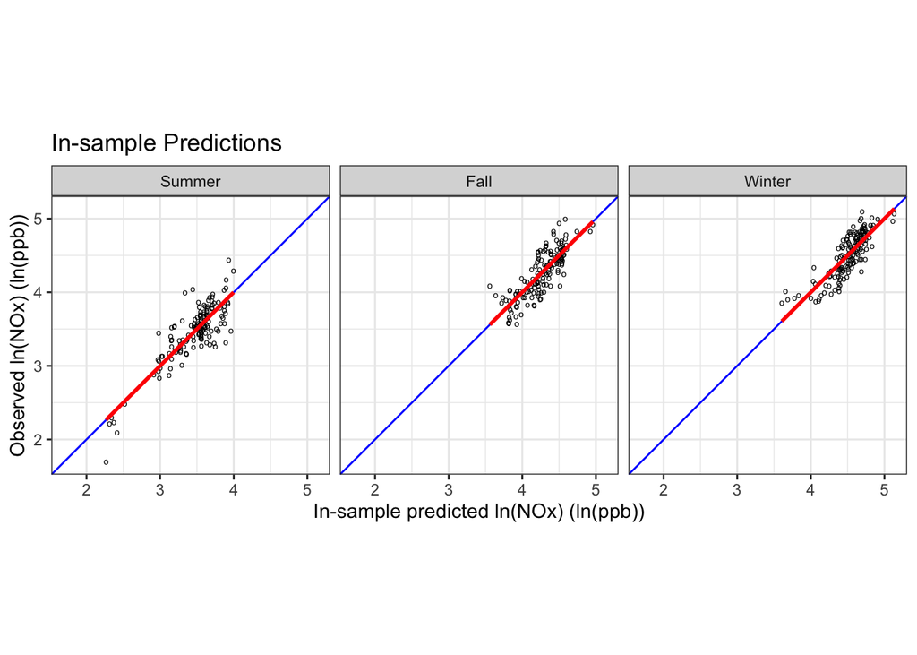

```r
#-----plot obs pred in sample-----

# calculate range of data
r <- range(season_mods[, c("ln_nox", ".fitted")])

# plot observations vs predictions for each season
ggplot(season_mods, aes(x = .fitted, y = ln_nox)) +
  geom_point(shape = "o") +
  facet_wrap(~seasonfac, nrow = 1) +
  lims(x = r, y = r) +
  coord_fixed() +
  geom_abline(intercept = 0, slope = 1, color = "blue") +
  geom_smooth(method = "lm", se = FALSE, color = "red") +
  labs(title = "In-sample Predictions",
       x = "In-sample predicted ln(NOx) (ln(ppb))",
       y = "Observed ln(NOx) (ln(ppb))"
       ) +
  theme_bw()
```

## Calculating predictions programmatically

In `Week3Lab.Rmd` we specified each of the out-of-sample predictions we were interested in separately, for example:

```
fall_preds_from_summer <-
  predict(lm_summer, snapshot[snapshot$season == 2,], interval = "prediction")
```

This is quite clear what’s happening, but again, it requires us to specify the model, the data subset, and the object name for each set of out-of-sample predictions of interest.

Next we’ll demonstrate how to calculate the season-specific predictions in the dataset for all seasons programmatically. While `augment()` conveniently gave us “in-sample” predictions, the following approach will give us both “in-sample” predictions (e.g. using the summer model to make predictions in summer) and “out-of-sample” predictions (e.g. using the summer model to make predictions in winter). The extra step involved with this approach comes after this chunk. It is selecting the output of interest, for example, the “Winter_” columns from the Summer “seasonfac” rows.

```r
#-----predictions with dplyr-----

# first, extract models from earlier regression procedures for convenience,
# setting the names of the models to match with their season
models <- season_mods_nested$model %>%
  setNames(as.character(season_mods_nested$seasonfac))

# use lapply and an anonymous function to loop through the models
allseas_both <- lapply(names(models), function(i){

  # add the predictions, intervals, and residuals for each season
  predict(models[[i]], snapshot, interval = "prediction") %>%
    as_tibble() %>%
    mutate(resid = snapshot[["ln_nox"]]-fit) %>%

    # rename columns to correspond to the season model
    rename_all(function(x){paste0(i, "_", x)})

  }) %>%

  # bind list of dataframes together
  reduce(cbind) %>%

  # add to snapshot dataframe
  bind_cols(snapshot, .)

# inspect predictions and residuals
allseas_both %>%
  select(seasonfac, ln_nox, matches("_fit|_lwr|_upr|_resid")) %>%
  mutate_if(is.double, round, 3)
```

```
# A tibble: 449 × 14
   seasonfac ln_nox Summer_fit Summer_lwr Summer_upr Summer_resid Fall_fit
   <fct>      <dbl>      <dbl>      <dbl>      <dbl>        <dbl>    <dbl>
 1 Summer      3.48       3.55       3.13       3.98       -0.07      4.07
 2 Summer      3.62       3.62       3.20       4.04        0.001     4.22
 3 Summer      3.81       3.62       3.20       4.04        0.198     4.22
 4 Summer      3.52       3.61       3.19       4.03       -0.093     4.21
 5 Summer      3.60       3.6        3.18       4.02       -0.005     4.17
 6 Summer      3.49       3.55       3.13       3.97       -0.057     4.03
 7 Summer      3.53       3.49       3.07       3.91        0.044     4.39
 8 Summer      3.44       3.53       3.12       3.95       -0.099     4.53
 9 Summer      3.55       3.55       3.13       3.97       -0.003     4.56
10 Summer      3.43       3.56       3.14       3.98       -0.131     4.57
# ℹ 439 more rows
# ℹ 7 more variables: Fall_lwr <dbl>, Fall_upr <dbl>, Fall_resid <dbl>,
#   Winter_fit <dbl>, Winter_lwr <dbl>, Winter_upr <dbl>, Winter_resid <dbl>
```

As we noted above, assessing the the quality of the predictions, as we did in `Week3Lab.Rmd` requires us to specify the data of interest since we’ve produced all predictions together:

```r
#-----prediction assessment

# summer in-sample
paste("summer in-sample R2:  ",
with(allseas_both %>% filter(seasonfac == "Summer"),
     round(cor(ln_nox, Summer_fit)^2, 3)) )
```

```
[1] "summer in-sample R2:   0.725"
```

```r
# summer out-of-sample (from winter model)
paste("summer out-of-sample R2 (from winter model):  ",
with(allseas_both %>% filter(seasonfac == "Summer"),
     round(cor(ln_nox, Winter_fit)^2, 3)) )
```

```
[1] "summer out-of-sample R2 (from winter model):   0.247"
```

## Plot predictions

We can define a flexible plot function to prevent repeating our plotting code: (Note that we will describe how to write functions in the Week 4 lab.)

```r
#-----define plot function-----

# make plot function
plot_func <- function(df = allseas_both, x_var, y_var, seas,
                      x_lab, y_lab, plot_title){

  # create function variable names with `enquo`
  x <- enquo(x_var)
  y <- enquo(y_var)

  # get range of data to define the plotting range in the axes
  r <- df %>%
    filter(seasonfac == seas) %>%
    select(Summer_fit, Fall_fit, Winter_fit, ln_nox) %>%
    range()

  # make plots
  df %>%
    filter(seasonfac == seas) %>%
    ggplot(aes(x = !!x, y = !!y)) +
    geom_point(shape = "o", alpha = 0.8) +
    lims(x = r, y = r) +
    coord_fixed() +
    geom_abline(intercept = 0, slope = 1, color = "blue") +
    geom_smooth(method = "lm", se = FALSE, color = "red") +
    labs(title = plot_title,
         x = x_lab,
         y = y_lab
         ) +
    theme_bw()

}
```

With the `allseas_both` dataframe (specified by default) we can plot in- and out-of-sample predictions like we did in `Week3Lab.Rmd` with our function:

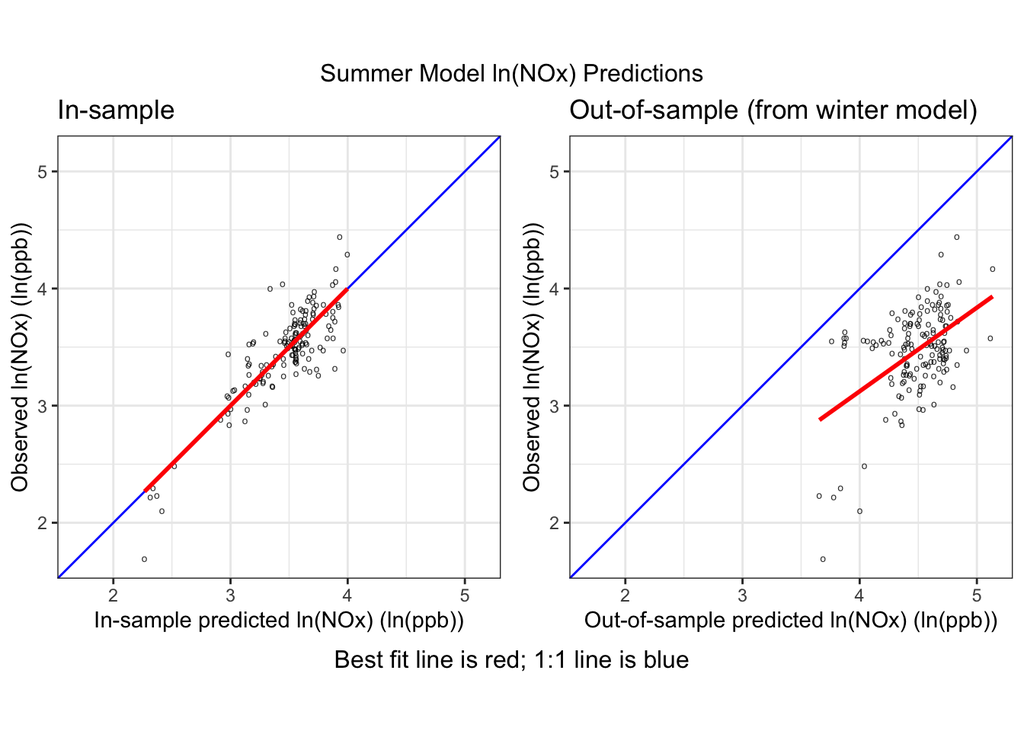

```r
#-----summer in and out of sample-----

# plot the predictions vs. data for summer, both in-sample and out of sample

# in-sample plot
p_in <- plot_func(x_var = Summer_fit, y_var = ln_nox, seas = "Summer",
                  x_lab = "In-sample predicted ln(NOx) (ln(ppb))",
                  y_lab = "Observed ln(NOx) (ln(ppb))",
                  plot_title = "In-sample")

# out-of-sample plot (predictions from the winter model)
p_out <- plot_func(x_var = Winter_fit, y_var = ln_nox, seas = "Summer",
                   x_lab = "Out-of-sample predicted ln(NOx) (ln(ppb))",
                   y_lab = "Observed ln(NOx) (ln(ppb))",
                   plot_title = "Out-of-sample (from winter model)" )

# combine plots
ggarrange(p_in, p_out, ncol = 2,
          top = "Summer Model ln(NOx) Predictions",
          bottom = "Best fit line is red; 1:1 line is blue")
```

Here is an alternate approach for plotting all predictions from a single season simultaneously using `facet wrap()`:

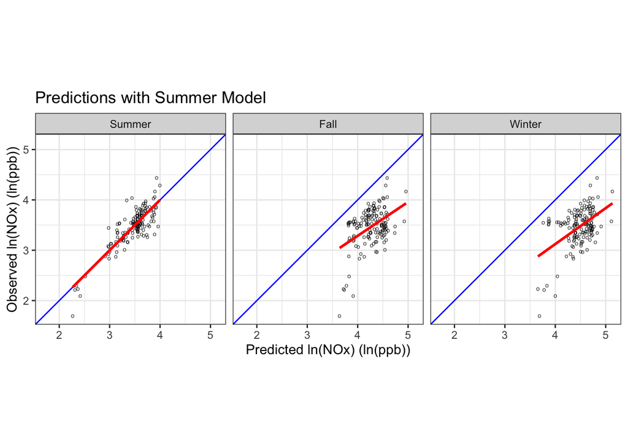

```r
#-----plot all predictions-----

# create temporary dataframe for ggplot
temp <- allseas_both %>%
  select(seasonfac, ln_nox, contains("_fit")) %>%
  filter(seasonfac == "Summer") %>%
  pivot_longer(cols = contains("_fit"), names_to = "season_fit",
               values_to = "fit") %>%
  mutate(season_fit = factor(str_remove(season_fit, "_fit"),
                             levels = c("Summer", "Fall", "Winter")) )

# get range for plots
  r <- temp %>%
    select(fit, ln_nox) %>%
    range()

# make plot
pred_plot <- ggplot(data = temp, aes(x = fit, y = ln_nox) ) +
    geom_point(shape = "o", alpha = 0.8) +
    facet_wrap(~season_fit, nrow = 1) +
    lims(x = r, y = r) +
    coord_fixed() +
    geom_abline(intercept = 0, slope = 1, color = "blue") +
    geom_smooth(method = "lm", se = FALSE, color = "red") +
    labs(title = "Predictions with Summer Model",
         x = "Predicted ln(NOx) (ln(ppb))",
         y = "Observed ln(NOx) (ln(ppb))"
         ) +
    theme_bw()

# show plot
pred_plot
```

# Appendix

```r
#-----setup-----
# clear work space of all objects and unload all extra (non-base) packages
rm(list = ls(all = TRUE))
if (!is.null(sessionInfo()$otherPkgs)) {
    res <- suppressWarnings(
        lapply(paste('package:', names(sessionInfo()$otherPkgs), sep=""),
               detach, character.only=TRUE, unload=TRUE, force=TRUE))

}

#-----load libraries pacman-----

# Load pacman into memory, installing as needed
my_repo <- 'http://cran.r-project.org'
if (!require("pacman")) {install.packages("pacman", repos = my_repo)}

# Load the other packages, installing as needed.  Some reasons for packages:
pacman::p_load(knitr, dplyr, ggplot2, egg, tidyr, broom, purrr, stringr)

#-----directory organization and read data-----

# specify working directory
project_path <- getwd()

# create "Datasets" directory if one does not already exist
dir.create(file.path(project_path,"Datasets"), showWarnings=FALSE, recursive = TRUE)

# specify data path
data_path <- file.path(project_path,"Datasets")

# specify the file name and path
file_name <- "allseasonsR.rds"
file_path <- file.path(data_path, file_name)

# Download the file if it is not already present
if (!file.exists(file_path)) {
    url <- paste("https://staff.washington.edu/high/envh556/Datasets",
                 file_name, sep = '/')
    download.file(url = url, destfile = file_path)
}

# Output a warning message if the file cannot be found
if (file.exists(file_path)) {
    snapshot <- readRDS(file_path)
} else warning(paste("Can't find", file_name, "!"))

# remove temporary variables
rm(url, file_name, file_path, data_path)

#-----prep snapshot-----

# transform snapshot dataframe to tibble and modify season factor
snapshot <- snapshot %>%
  as_tibble() %>%
  mutate(seasonfac = factor(str_remove(seasonfac, "[:digit:]"),
         levels = c("Summer", "Fall", "Winter")) )

# create season variable (to be used throughout analysis)
seasons <- unique(snapshot$seasonfac)

#-----summarize ln_nox-----

# frequencies only
summary(snapshot$seasonfac)

# descriptive statistics
snapshot_summary <- snapshot %>%
    group_by(seasonfac) %>%
    summarise(N = n(),
              Mean = mean(ln_nox),
              SD = sd(ln_nox),
              GM = exp(mean(ln_nox)),
              GSD = exp(sd(ln_nox)),
              .groups = "drop") %>%
    mutate_if(is.double, round, digits = 2)

# show summary
snapshot_summary

#-----season-specific boxplots-----

ggplot(snapshot, aes(x = seasonfac, y = ln_nox, fill = seasonfac)) +
    geom_boxplot() +
    labs(x = "Season",
         y = "ln(NOx) (ln(ppb)",
         color = "Season",
         fill = "Season") +
    theme_article()

#-----regression for association-----

# Common model (Table 4), season-specific LUR from Mercer et al, 2011

# specify the "common model"
frml <-
  as.formula(ln_nox ~ D2A1 + A1_50 + A23_400 + Pop_5000 + D2C + Int_3000 + D2Comm)

# create tibble with nested seasonal models
season_mods_nested <- snapshot %>%

  # group by season, then "nest"
  group_by(seasonfac) %>%
  nest() %>%

  # fit regression model for each season and generate summary, glance, augment,
  # and in-sample prediction outputs with prediction intervals.
  mutate(model = map(data, ~lm(frml, data = .x)),
         summary = map(model, summary),
         glanced = map(model, glance),
         augmented = map(model, augment),
         preds = map2(model, data,
                      ~as.data.frame(predict(.x, .y, interval = "prediction")) )

         )

# show tibble
season_mods_nested
#-----unnest-----

# unnest glanced object - `glance()` provides model summaries
unnest(season_mods_nested, glanced)

# unnest augmented dataframe for ".fitted" and ".resid" values. Unfortunately,
# the prediction intervals are not provided with `augment()`. We'll now assign
# this output to the `season_mods` object, but this could have been accomplished
# by continuing the pipeline in the previous chunk. We split up this pipeline
# just to demonstrate how to access the different objects produced in the nest
# workflow.
season_mods <- unnest(season_mods_nested, augmented)

# show augmented season_mods object
season_mods
#-----plot obs pred in sample-----

# calculate range of data
r <- range(season_mods[, c("ln_nox", ".fitted")])

# plot observations vs predictions for each season
ggplot(season_mods, aes(x = .fitted, y = ln_nox)) +
  geom_point(shape = "o") +
  facet_wrap(~seasonfac, nrow = 1) +
  lims(x = r, y = r) +
  coord_fixed() +
  geom_abline(intercept = 0, slope = 1, color = "blue") +
  geom_smooth(method = "lm", se = FALSE, color = "red") +
  labs(title = "In-sample Predictions",
       x = "In-sample predicted ln(NOx) (ln(ppb))",
       y = "Observed ln(NOx) (ln(ppb))"
       ) +
  theme_bw()

#-----predictions with dplyr-----

# first, extract models from earlier regression procedures for convenience,
# setting the names of the models to match with their season
models <- season_mods_nested$model %>%
  setNames(as.character(season_mods_nested$seasonfac))

# use lapply and an anonymous function to loop through the models
allseas_both <- lapply(names(models), function(i){

  # add the predictions, intervals, and residuals for each season
  predict(models[[i]], snapshot, interval = "prediction") %>%
    as_tibble() %>%
    mutate(resid = snapshot[["ln_nox"]]-fit) %>%

    # rename columns to correspond to the season model
    rename_all(function(x){paste0(i, "_", x)})

  }) %>%

  # bind list of dataframes together
  reduce(cbind) %>%

  # add to snapshot dataframe
  bind_cols(snapshot, .)

# inspect predictions and residuals
allseas_both %>%
  select(seasonfac, ln_nox, matches("_fit|_lwr|_upr|_resid")) %>%
  mutate_if(is.double, round, 3)

#-----prediction assessment

# summer in-sample
paste("summer in-sample R2:  ",
with(allseas_both %>% filter(seasonfac == "Summer"),
     round(cor(ln_nox, Summer_fit)^2, 3)) )

# summer out-of-sample (from winter model)
paste("summer out-of-sample R2 (from winter model):  ",
with(allseas_both %>% filter(seasonfac == "Summer"),
     round(cor(ln_nox, Winter_fit)^2, 3)) )

#-----define plot function-----

# make plot function
plot_func <- function(df = allseas_both, x_var, y_var, seas,
                      x_lab, y_lab, plot_title){

  # create function variable names with `enquo`
  x <- enquo(x_var)
  y <- enquo(y_var)

  # get range of data to define the plotting range in the axes
  r <- df %>%
    filter(seasonfac == seas) %>%
    select(Summer_fit, Fall_fit, Winter_fit, ln_nox) %>%
    range()

  # make plots
  df %>%
    filter(seasonfac == seas) %>%
    ggplot(aes(x = !!x, y = !!y)) +
    geom_point(shape = "o", alpha = 0.8) +
    lims(x = r, y = r) +
    coord_fixed() +
    geom_abline(intercept = 0, slope = 1, color = "blue") +
    geom_smooth(method = "lm", se = FALSE, color = "red") +
    labs(title = plot_title,
         x = x_lab,
         y = y_lab
         ) +
    theme_bw()

}

#-----summer in and out of sample-----

# plot the predictions vs. data for summer, both in-sample and out of sample

# in-sample plot
p_in <- plot_func(x_var = Summer_fit, y_var = ln_nox, seas = "Summer",
                  x_lab = "In-sample predicted ln(NOx) (ln(ppb))",
                  y_lab = "Observed ln(NOx) (ln(ppb))",
                  plot_title = "In-sample")

# out-of-sample plot (predictions from the winter model)
p_out <- plot_func(x_var = Winter_fit, y_var = ln_nox, seas = "Summer",
                   x_lab = "Out-of-sample predicted ln(NOx) (ln(ppb))",
                   y_lab = "Observed ln(NOx) (ln(ppb))",
                   plot_title = "Out-of-sample (from winter model)" )

# combine plots
ggarrange(p_in, p_out, ncol = 2,
          top = "Summer Model ln(NOx) Predictions",
          bottom = "Best fit line is red; 1:1 line is blue")

#-----plot all predictions-----

# create temporary dataframe for ggplot
temp <- allseas_both %>%
  select(seasonfac, ln_nox, contains("_fit")) %>%
  filter(seasonfac == "Summer") %>%
  pivot_longer(cols = contains("_fit"), names_to = "season_fit",
               values_to = "fit") %>%
  mutate(season_fit = factor(str_remove(season_fit, "_fit"),
                             levels = c("Summer", "Fall", "Winter")) )

# get range for plots
  r <- temp %>%
    select(fit, ln_nox) %>%
    range()

# make plot
pred_plot <- ggplot(data = temp, aes(x = fit, y = ln_nox) ) +
    geom_point(shape = "o", alpha = 0.8) +
    facet_wrap(~season_fit, nrow = 1) +
    lims(x = r, y = r) +
    coord_fixed() +
    geom_abline(intercept = 0, slope = 1, color = "blue") +
    geom_smooth(method = "lm", se = FALSE, color = "red") +
    labs(title = "Predictions with Summer Model",
         x = "Predicted ln(NOx) (ln(ppb))",
         y = "Observed ln(NOx) (ln(ppb))"
         ) +
    theme_bw()

# show plot
pred_plot
#-----session information----

# print R session information
sessionInfo()

#-----code appendix----
#-----functions----

# Show the names of all functions defined in the .Rmd
# (e.g. loaded in the environment)
lsf.str()

# Show the definitions of all functions loaded into the current environment
lapply(c(lsf.str()), getAnywhere)
```

```r
#-----functions----

# Show the names of all functions defined in the .Rmd
# (e.g. loaded in the environment)
lsf.str()
```

```
plot_func : function (df = allseas_both, x_var, y_var, seas, x_lab, y_lab, plot_title)
```

```r
# Show the definitions of all functions loaded into the current environment
lapply(c(lsf.str()), getAnywhere)
```

```
[[1]]
A single object matching 'plot_func' was found
It was found in the following places
  .GlobalEnv
with value

<srcref: file "" chars 4:14 to 32:1>
<bytecode: 0x13f5f0d80>
```